# SI 544 FA 2020 Problem Set 1

Matthew Garvin

# SI 544 FA 2020: Problem Set #1

You were introduced to the COVID-19 Data Hub (Guidotti & Ardia, 2020) in this week’s discussion. We are going to delve a bit deeper into that data set for this assignment. We will focus on cleaning and manipulating the data so it’s suitable for generating plots to help us understand the spread of COVID-19.

Google Mobility Reports (GMR) use pooled data to report where people are. A example of a mobility report can be accessed via https://www.gstatic.com/covid19/mobility/2020-09-11_US_Mobility_Report_en.pdf. The GMR provides an indication of the percent change from baseline for the following types of locations: retail and recreation, grocery and pharmacy, parks, transit stations, workplaces, and residential. The GMR data can be joined to the COVID-19 Data Hub data set by using the `gmr=` option when the COVID-19 data set is loaded (see first R block below).

In addition to the GMR, the authors of the COVID-19 Data Hub have made it easy to link the COVID-19 data set with data from the World Bank. Of particular interest are two indicators: Total GDP and number of hospital beds per 1000 people. The first R block below loads country-level data including the two World Bank indicators mentioned and the second one loads province-level data for Canada (Canada’s provinces are analogous to states in the USA).

```r
library(tidyverse)
library(COVID19)
```

```r
wb <- c("gdp" = "NY.GDP.MKTP.CD", "hosp_beds" = "SH.MED.BEDS.ZS", "diab_prev" = "SH.STA.DIAB.ZS", "water_sanitation" = "IE.PPI.WATR.CD")
all_countries <- covid19(wb = wb)
```

[output not shown]

```r
# NOTE: Running this block will take a long time -- be patient!
#       This will also be run when you knit your notebook,
#       so knitting will also take a few minutes
gmr <- "https://www.gstatic.com/covid19/mobility/Global_Mobility_Report.csv"
canada <- covid19(country='CAN',gmr = gmr, level=2)
```

[output not shown]

To complete this assignment, answer the following questions. For questions 1-5 use the “all countries” data set (the dataframe named `all_countries`). Your answers will change depending on when you do your work because the dataset is updated periodically; keep that in mind when sharing your results with your peers.

1. How many different countries are represented in the country-level data set?

```r
# Type your code here
diff_countries <- all_countries %>%
   group_by(administrative_area_level_1) %>%
   count() %>%
   rename(Country = administrative_area_level_1,
          Frequency = n)
```

Answer: 196 different countries

2. What are the earliest and latest dates in the country-level data set?

```r
# Type your code here
all_countries %>%
   arrange(date)
```

```
## # A tibble: 48,220 x 39
## # Groups:   id [196]
##    iso_alpha_3 id    date       tests confirmed recovered deaths  hosp  vent
##    <chr>       <chr> <date>     <int>     <int>     <int>  <int> <int> <int>
##  1 THA         THA   2020-01-01    NA         0         0      0    NA    NA
##  2 THA         THA   2020-01-02    NA         0         0      0    NA    NA
##  3 CHN         CHN   2020-01-03    NA         0        NA      0    NA    NA
##  4 THA         THA   2020-01-03    NA         0         0      0    NA    NA
##  5 CHN         CHN   2020-01-04    NA         1        NA      0    NA    NA
##  6 THA         THA   2020-01-04    NA         0         0      0    NA    NA
##  7 CHN         CHN   2020-01-05    NA         1        NA      0    NA    NA
##  8 THA         THA   2020-01-05    NA         0         0      0    NA    NA
##  9 CHN         CHN   2020-01-06    NA         4        NA      0    NA    NA
## 10 THA         THA   2020-01-06    NA         0         0      0    NA    NA
## # ... with 48,210 more rows, and 30 more variables: icu <int>,
## #   population <int>, school_closing <int>, workplace_closing <int>,
## #   cancel_events <int>, gatherings_restrictions <int>,
## #   transport_closing <int>, stay_home_restrictions <int>,
## #   internal_movement_restrictions <int>,
## #   international_movement_restrictions <int>, information_campaigns <int>,
## #   testing_policy <int>, contact_tracing <int>, stringency_index <dbl>,
## #   iso_alpha_2 <chr>, iso_numeric <int>, currency <chr>,
## #   administrative_area_level <int>, administrative_area_level_1 <chr>,
## #   administrative_area_level_2 <lgl>, administrative_area_level_3 <lgl>,
## #   latitude <dbl>, longitude <dbl>, key <lgl>, key_apple_mobility <chr>,
## #   key_google_mobility <chr>, gdp <dbl>, hosp_beds <dbl>, diab_prev <dbl>,
## #   water_sanitation <dbl>
```

```r
all_countries %>%
   arrange(desc(date))
```

```
## # A tibble: 48,220 x 39
## # Groups:   id [196]
##    iso_alpha_3 id    date         tests confirmed recovered deaths  hosp  vent
##    <chr>       <chr> <date>       <int>     <int>     <int>  <int> <int> <int>
##  1 AUS         AUS   2020-09-24  7.39e6     26983     24137    816    81     7
##  2 AUT         AUT   2020-09-24 NA             NA     31661    765    NA    NA
##  3 CAC         CAC   2020-09-24 NA            149       149      0    NA    NA
##  4 CHL         CHL   2020-09-24  3.11e6    451634        NA  12469  3428    NA
##  5 CHN         CHN   2020-09-24 NA          90918        NA   4745    NA    NA
##  6 IRL         IRL   2020-09-24  1.11e6        NA        NA     NA    94    NA
##  7 ITA         ITA   2020-09-24  1.08e7    304323    221762  35781  2977    NA
##  8 JPN         JPN   2020-09-24  1.89e6     80505     72522   1536  5989    NA
##  9 LVA         LVA   2020-09-24  3.04e5      1594        NA     36    NA    NA
## 10 PRT         PRT   2020-09-24 NA          71156     46676   1931   588    NA
## # ... with 48,210 more rows, and 30 more variables: icu <int>,
## #   population <int>, school_closing <int>, workplace_closing <int>,
## #   cancel_events <int>, gatherings_restrictions <int>,
## #   transport_closing <int>, stay_home_restrictions <int>,
## #   internal_movement_restrictions <int>,
## #   international_movement_restrictions <int>, information_campaigns <int>,
## #   testing_policy <int>, contact_tracing <int>, stringency_index <dbl>,
## #   iso_alpha_2 <chr>, iso_numeric <int>, currency <chr>,
## #   administrative_area_level <int>, administrative_area_level_1 <chr>,
## #   administrative_area_level_2 <lgl>, administrative_area_level_3 <lgl>,
## #   latitude <dbl>, longitude <dbl>, key <lgl>, key_apple_mobility <chr>,
## #   key_google_mobility <chr>, gdp <dbl>, hosp_beds <dbl>, diab_prev <dbl>,
## #   water_sanitation <dbl>
```

3. Use the country-level data set to create a histogram that shows the distribution of values for the number of hospital beds per 1000 people. Draw a red vertical line that shows the median value on the histogram (hint: use geom_vline(…) as an additional layer in your ggplot). (hint: watch out for missing values. You may find `na.rm=TRUE` helpful)

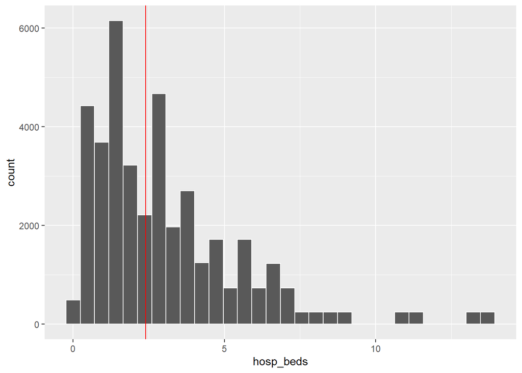

```r
# Type your code here

ggplot(data = all_countries, mapping = aes(x = hosp_beds)) +
  geom_histogram(color="white") +
   geom_vline(xintercept = median(all_countries$hosp_beds, na.rm = TRUE), color="red")
```

```r
median(all_countries$hosp_beds, na.rm = TRUE)
```

```
## [1] 2.4
```

Answer: Median = 2.4 hospital beds per 1000 people

4. Use the country-level data set to create a scatterplot of the **total** number of recoveries (on the y-axis) vs. the **maximum** number of hospital beds per 1000 people (on the x-axis) in that country. What does the plot tell you?

```r
# Type your code here

dat_filter <- all_countries %>%
   filter(date == "2020-09-20") %>%
   select(id, date, recovered, administrative_area_level_1, hosp_beds) %>%
   summarise(max_bed=replace_na(max(hosp_beds), 0), total_rec=sum(recovered, na.rm = TRUE))
dat_filter
```

```
## # A tibble: 196 x 3
##    id    max_bed total_rec
##    <chr>   <dbl>     <int>
##  1 AFG       0.5     32576
##  2 AGO       0        1445
##  3 ALB       2.9      6940
##  4 AND       0        1164
##  5 ARE       1.2     74273
##  6 ARG       5      488231
##  7 ARM       4.2     42608
##  8 ASM       0           0
##  9 ATG       3.8        92
## 10 AUS       3.8     23870
## # ... with 186 more rows
```

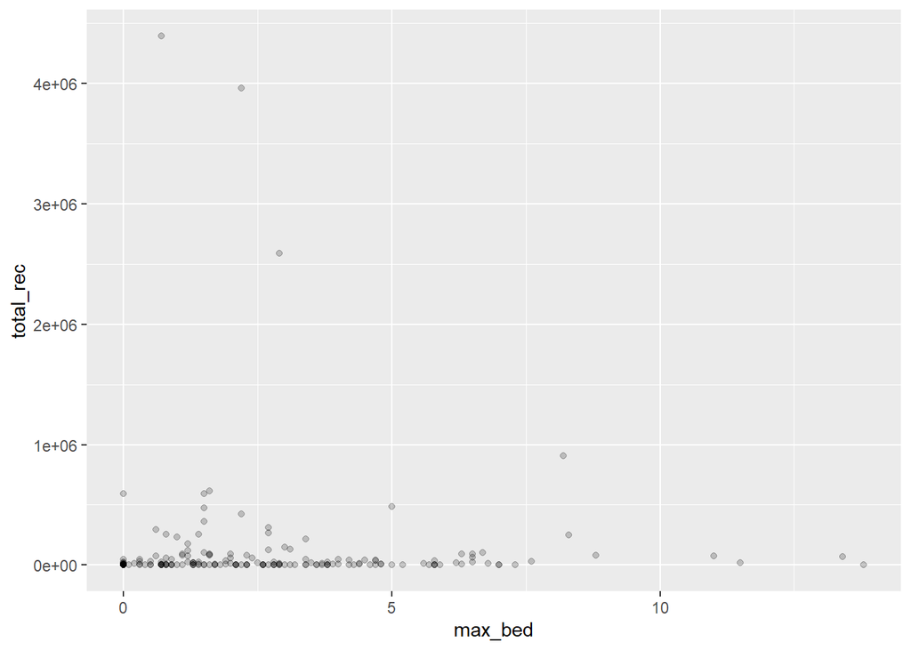

```r
ggplot(data = dat_filter, mapping = aes(max_bed, total_rec)) +
   geom_point(alpha = 0.2)
```

5. Select another World Bank indicator from https://data.worldbank.org/indicator/ and create a scatterplot between that indicator on the x-axis and the number of confirmed cases (the “confirmed” column) on the y-axis. You can download a list of all indicators from http://databank.worldbank.org/data/download/site-content/WDI_CETS.xls. Explain why you chose the indicator you did and provide a brief description of it.

You will need to add the indicator to the list of indicators in the R block that you use to read in the data. For example, if you chose “Literacy rate, adult total (% of people ages 15 and above)?”, you would notice that the URL for the resulting page is https://data.worldbank.org/indicator/SE.ADT.LITR.ZS?view=chart. In that case, the indicator name would be “SE.ADT.LITR.ZS” and your code to read in the data would be:

```
wb <- c("gdp" = "NY.GDP.MKTP.CD", "hosp_beds" = "SH.MED.BEDS.ZS", "literacy_rate" = "SE.ADT.LITR.ZS")
all_countries <- covid19(wb = wb)
```

Note: you may not use SE.ADT.LITR.ZS as your chosen indicator; choose something else!

Answer: I selected diabetes prevalence as a new indicator for the x-axis. I chose this indicator for two reasons: 1) it’s a known comordibity of COVID; 2) it is a non-communicable disease associated with increased rates of sedentary lifestyle common in industrialized and developing nations. With this plot I am looking to see if nations with higher rates of diabetes is tied to reduced recovery rates.

This indicator shows diabetes prevalence as a percentage of population between the ages of 20-79

```r
# Type your code here

new_dat_filter <- all_countries %>%
   filter(date == "2020-09-21") %>%
   select(id, recovered, diab_prev)
   #summarise(total_rec=sum(recovered, na.rm = TRUE))
new_dat_filter
```

```
## # A tibble: 196 x 3
## # Groups:   id [196]
##    id    recovered diab_prev
##    <chr>     <int>     <dbl>
##  1 AFG       32576       9.2
##  2 AGO        1449       4.5
##  3 ALB        6995       9
##  4 AND        1199       7.7
##  5 ARE       75086      16.3
##  6 ARG      508563       5.9
##  7 ARM       42637       6.1
##  8 ASM          NA      NA
##  9 ATG          92      13.1
## 10 AUS       23965       5.6
## # ... with 186 more rows
```

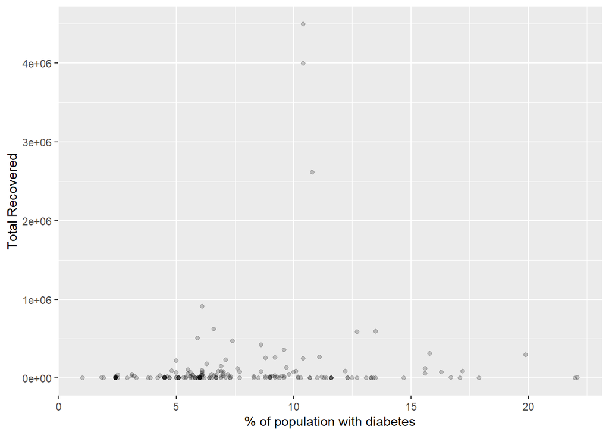

```r
axs <- ggplot(data = new_dat_filter, mapping = aes(diab_prev, recovered)) +
   geom_point(alpha = 0.2) +
   labs(x = "% of population with diabetes", y = "Total Recovered")
axs
```

```r
#axs + scale_x_continuous(breaks = c(2000, 4000), labels = c("2k", "4k"))
```

For questions 6-10 use the province-level data set for Canada (the dataframe named `canada`). Your answers will change depending on when you do your work because the dataset is updated periodically; keep that in mind when sharing your results with your peers.

6. How many tests have been conducted in Canada in total?

```r
# Type your code here
can_dat_filter <- canada %>%
   filter(date == "2020-09-20") %>%
   select(date, key_google_mobility, id, tests) %>%
   summarise(total_tests=sum(tests, na.rm = TRUE))
can_dat_filter
```

```
## # A tibble: 13 x 2
##    id       total_tests
##    <chr>          <int>
##  1 015d95fc       33680
##  2 2a9fd65a      157071
##  3 38791b01        3049
##  4 7fc88543        2228
##  5 83fc0fa9     3432561
##  6 a7ce33b9     1361889
##  7 b91ff4d1       88584
##  8 c229681f      383264
##  9 d07806cb       37833
## 10 d177e539       60681
## 11 e4c07903      144178
## 12 e61d6191      909443
## 13 eef40c88        3944
```

```r
all_tests <- sum(can_dat_filter$total_tests)
all_tests
```

[output not shown]

7. Which Canadian province has conducted the most tests to date?

```r
# Type your code here
can_province <- canada %>%
   arrange(desc(tests))
can_province
```

```
## # A tibble: 2,602 x 46
## # Groups:   id [13]
##    date       key_google_mobi~ id     tests confirmed recovered deaths  hosp
##    <date>     <chr>            <chr>  <int>     <int>     <int>  <int> <int>
##  1 2020-09-23 CA, Ontario      83fc~ 3.53e6     48087     41600   2835    NA
##  2 2020-09-22 CA, Ontario      83fc~ 3.50e6     47752     41342   2832    NA
##  3 2020-09-21 CA, Ontario      83fc~ 3.46e6     47274     41146   2829    NA
##  4 2020-09-20 CA, Ontario      83fc~ 3.43e6     46849     40968   2827    NA
##  5 2020-09-19 CA, Ontario      83fc~ 3.39e6     46484     40777   2826    NA
##  6 2020-09-18 CA, Ontario      83fc~ 3.36e6     46077     40600   2825    NA
##  7 2020-09-17 CA, Ontario      83fc~ 3.32e6     45676     40424   2825    NA
##  8 2020-09-16 CA, Ontario      83fc~ 3.29e6     45383     40245   2822    NA
##  9 2020-09-15 CA, Ontario      83fc~ 3.26e6     45068     40091   2820    NA
## 10 2020-09-14 CA, Ontario      83fc~ 3.23e6     44817     39974   2816    NA
## # ... with 2,592 more rows, and 38 more variables: vent <int>, icu <int>,
## #   population <dbl>, school_closing <int>, workplace_closing <int>,
## #   cancel_events <int>, gatherings_restrictions <int>,
## #   transport_closing <int>, stay_home_restrictions <int>,
## #   internal_movement_restrictions <int>,
## #   international_movement_restrictions <int>, information_campaigns <int>,
## #   testing_policy <int>, contact_tracing <int>, stringency_index <dbl>,
## #   iso_alpha_3 <chr>, iso_alpha_2 <chr>, iso_numeric <int>, currency <chr>,
## #   administrative_area_level <int>, administrative_area_level_1 <chr>,
## #   administrative_area_level_2 <chr>, administrative_area_level_3 <lgl>,
## #   latitude <dbl>, longitude <dbl>, key <chr>, key_apple_mobility <chr>,
## #   key_alpha_2 <chr>, key_numeric <int>, metro_area <chr>,
## #   iso_3166_2_code <chr>, census_fips_code <int>,
## #   retail_and_recreation_percent_change_from_baseline <int>,
## #   grocery_and_pharmacy_percent_change_from_baseline <int>,
## #   parks_percent_change_from_baseline <int>,
## #   transit_stations_percent_change_from_baseline <int>,
## #   workplaces_percent_change_from_baseline <int>,
## #   residential_percent_change_from_baseline <int>
```

Answer: Ontario

8. Which Canadian province has the highest recovery rate (where recovery rate is calculated as the number of recovered cases divided by the number of confirmed cases)? Use the most up to date data as you can find using “COVID19” package.

```r
# Type your code here
can_recover <- canada %>%
   filter(date == "2020-09-19") %>%
   arrange(desc(recovered))
can_recover
```

```
## # A tibble: 13 x 46
## # Groups:   id [13]
##    date       key_google_mobi~ id     tests confirmed recovered deaths  hosp
##    <date>     <chr>            <chr>  <int>     <int>     <int>  <int> <int>
##  1 2020-09-19 CA, Quebec       a7ce~ 1.34e6     67080     58490   5797    NA
##  2 2020-09-19 CA, Ontario      83fc~ 3.39e6     46484     40777   2826    NA
##  3 2020-09-19 CA, Alberta      e61d~ 9.09e5     16381     14702    255    NA
##  4 2020-09-19 CA, British Col~ c229~ 3.79e5      7842      5797    223    NA
##  5 2020-09-19 CA, Saskatchewan e4c0~ 1.42e5      1787      1642     24    NA
##  6 2020-09-19 CA, Manitoba     2a9f~ 1.57e5      1558      1211     16    NA
##  7 2020-09-19 CA, Nova Scotia  b91f~ 8.80e4      1086      1021     65    NA
##  8 2020-09-19 CA, Newfoundlan~ d078~ 3.73e4       272       267      3    NA
##  9 2020-09-19 CA, New Brunswi~ d177~ 6.03e4       194       191      2    NA
## 10 2020-09-19 CA, Prince Edwa~ 015d~ 3.34e4        57        56      0    NA
## 11 2020-09-19 CA, Yukon        3879~ 3.05e3        15        15      0    NA
## 12 2020-09-19 CA, Northwest T~ eef4~ 3.94e3         5         5      0    NA
## 13 2020-09-19 CA, Nunavut      7fc8~ 2.20e3         0         0      0    NA
## # ... with 38 more variables: vent <int>, icu <int>, population <dbl>,
## #   school_closing <int>, workplace_closing <int>, cancel_events <int>,
## #   gatherings_restrictions <int>, transport_closing <int>,
## #   stay_home_restrictions <int>, internal_movement_restrictions <int>,
## #   international_movement_restrictions <int>, information_campaigns <int>,
## #   testing_policy <int>, contact_tracing <int>, stringency_index <dbl>,
## #   iso_alpha_3 <chr>, iso_alpha_2 <chr>, iso_numeric <int>, currency <chr>,
## #   administrative_area_level <int>, administrative_area_level_1 <chr>,
## #   administrative_area_level_2 <chr>, administrative_area_level_3 <lgl>,
## #   latitude <dbl>, longitude <dbl>, key <chr>, key_apple_mobility <chr>,
## #   key_alpha_2 <chr>, key_numeric <int>, metro_area <chr>,
## #   iso_3166_2_code <chr>, census_fips_code <int>,
## #   retail_and_recreation_percent_change_from_baseline <int>,
## #   grocery_and_pharmacy_percent_change_from_baseline <int>,
## #   parks_percent_change_from_baseline <int>,
## #   transit_stations_percent_change_from_baseline <int>,
## #   workplaces_percent_change_from_baseline <int>,
## #   residential_percent_change_from_baseline <int>
```

9. Create a bar plot that shows the number of tests conducted per 1000 people for each province in Canada. Use the most up to date data as you can find using “COVID19” package. (Hint: for Canada, the administrative_area_level_2 variable contains the province name.)

```r
# Type your code here

group_province <- canada %>%
   filter(date == "2020-09-20") %>%
   group_by(administrative_area_level_2) %>%
   select(administrative_area_level_2, population, tests) %>%
   mutate(tests_per_1000 = tests / population * 1000)
group_province
```

```
## # A tibble: 13 x 4
## # Groups:   administrative_area_level_2 [13]
##    administrative_area_level_2 population   tests tests_per_1000
##    <chr>                            <dbl>   <int>          <dbl>
##  1 Prince Edward Island            158158   33680          213.
##  2 Manitoba                       1377517  157071          114.
##  3 Yukon                            41078    3049           74.2
##  4 Nunavut                          38780    2228           57.5
##  5 Ontario                       14711827 3432561          233.
##  6 Quebec                         8537674 1361889          160.
##  7 Nova Scotia                     977457   88584           90.6
##  8 British Columbia               5110917  383264           75.0
##  9 Newfoundland and Labrador       521365   37833           72.6
## 10 New Brunswick                   779993   60681           77.8
## 11 Saskatchewan                   1181666  144178          122.
## 12 Alberta                        4413146  909443          206.
## 13 Northwest Territories            44904    3944           87.8
```

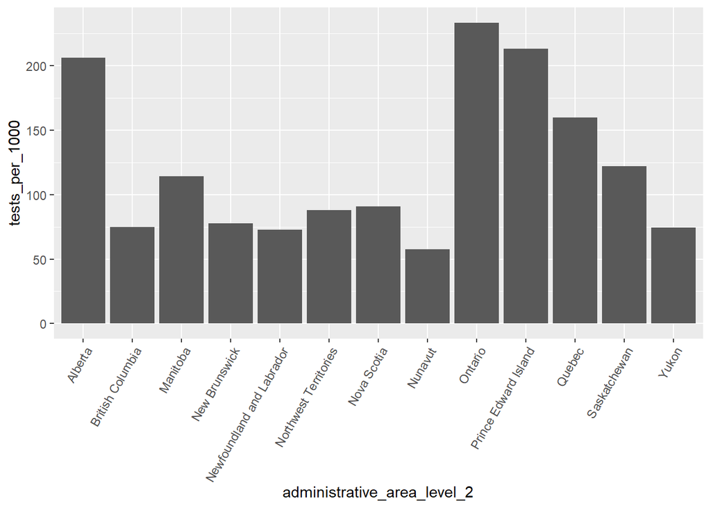

```r
group_province %>%
   ggplot(data = group_province, mapping = aes(x = administrative_area_level_2, y = tests_per_1000)) +
   theme(axis.text.x = element_text(angle=60, hjust=1)) +
   geom_col()
```

10. Ontario and British Columbia are two provinces in Canada. Create linegraphs that show how the percent change from baseline looks for each of the six types of locations (i.e. retail and recreation, grocery and pharmacy, parks, transit stations, workplaces, and residential) from the GMR for Ontario. You can experiment with creating one linegraph per location type or, alternatively, you can create multiple lines on one linegraph. Repeat this for British Columbia.

```r
# Type your code here
ontario <- canada %>%
   select(date, administrative_area_level_2, retail_and_recreation_percent_change_from_baseline, grocery_and_pharmacy_percent_change_from_baseline, parks_percent_change_from_baseline, transit_stations_percent_change_from_baseline, workplaces_percent_change_from_baseline, residential_percent_change_from_baseline) %>%
   filter(id == "83fc0fa9")
ontario
```

```
## # A tibble: 213 x 9
## # Groups:   id [1]
##    id    date       administrative_~ retail_and_recr~ grocery_and_pha~
##    <chr> <date>     <chr>                       <int>            <int>
##  1 83fc~ 2020-01-31 Ontario                        NA               NA
##  2 83fc~ 2020-02-08 Ontario                        NA               NA
##  3 83fc~ 2020-02-16 Ontario                        16               13
##  4 83fc~ 2020-02-21 Ontario                         1               -3
##  5 83fc~ 2020-02-24 Ontario                         2                2
##  6 83fc~ 2020-02-25 Ontario                         1                7
##  7 83fc~ 2020-02-26 Ontario                        -8               -5
##  8 83fc~ 2020-02-27 Ontario                       -13              -12
##  9 83fc~ 2020-02-29 Ontario                         5                6
## 10 83fc~ 2020-03-01 Ontario                        11               10
## # ... with 203 more rows, and 4 more variables:
## #   parks_percent_change_from_baseline <int>,
## #   transit_stations_percent_change_from_baseline <int>,
## #   workplaces_percent_change_from_baseline <int>,
## #   residential_percent_change_from_baseline <int>
```

```r
bc <- canada %>%
   select(date, administrative_area_level_2, retail_and_recreation_percent_change_from_baseline, grocery_and_pharmacy_percent_change_from_baseline, parks_percent_change_from_baseline, transit_stations_percent_change_from_baseline, workplaces_percent_change_from_baseline, residential_percent_change_from_baseline) %>%
   filter(id == "c229681f")
bc
```

```
## # A tibble: 213 x 9
## # Groups:   id [1]
##    id    date       administrative_~ retail_and_recr~ grocery_and_pha~
##    <chr> <date>     <chr>                       <int>            <int>
##  1 c229~ 2020-01-31 British Columbia               NA               NA
##  2 c229~ 2020-02-08 British Columbia               NA               NA
##  3 c229~ 2020-02-16 British Columbia               12                2
##  4 c229~ 2020-02-21 British Columbia                6                3
##  5 c229~ 2020-02-24 British Columbia                1                4
##  6 c229~ 2020-02-25 British Columbia                2                3
##  7 c229~ 2020-02-26 British Columbia                2                4
##  8 c229~ 2020-02-27 British Columbia                2                4
##  9 c229~ 2020-02-29 British Columbia                7                8
## 10 c229~ 2020-03-01 British Columbia                7                7
## # ... with 203 more rows, and 4 more variables:
## #   parks_percent_change_from_baseline <int>,
## #   transit_stations_percent_change_from_baseline <int>,
## #   workplaces_percent_change_from_baseline <int>,
## #   residential_percent_change_from_baseline <int>
```

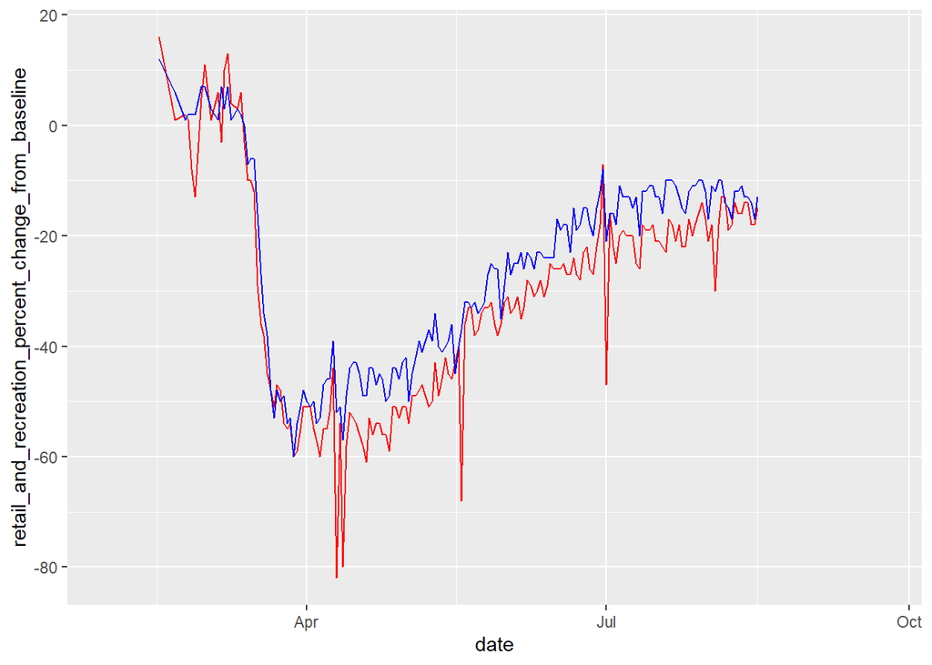

```r
retail_bc_ontario <- ggplot() +
   geom_line(data = ontario, mapping = aes(x = date, y = retail_and_recreation_percent_change_from_baseline), color = "red") +
   geom_line(data = bc, mapping = aes(x = date, y = retail_and_recreation_percent_change_from_baseline), color = "blue")
retail_bc_ontario
```

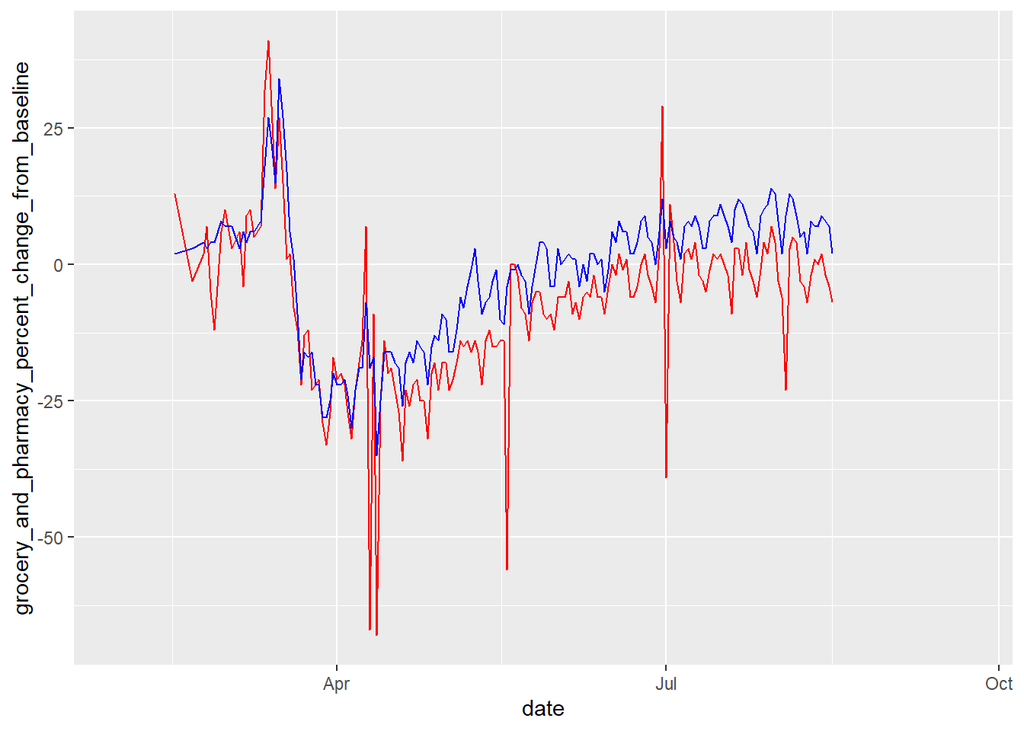

```r
grocery_bc_ontario <- ggplot() +
   geom_line(data = ontario, mapping = aes(x = date, y = grocery_and_pharmacy_percent_change_from_baseline), color = "red") +
   geom_line(data = bc, mapping = aes(x = date, y = grocery_and_pharmacy_percent_change_from_baseline), color = "blue")
grocery_bc_ontario
```

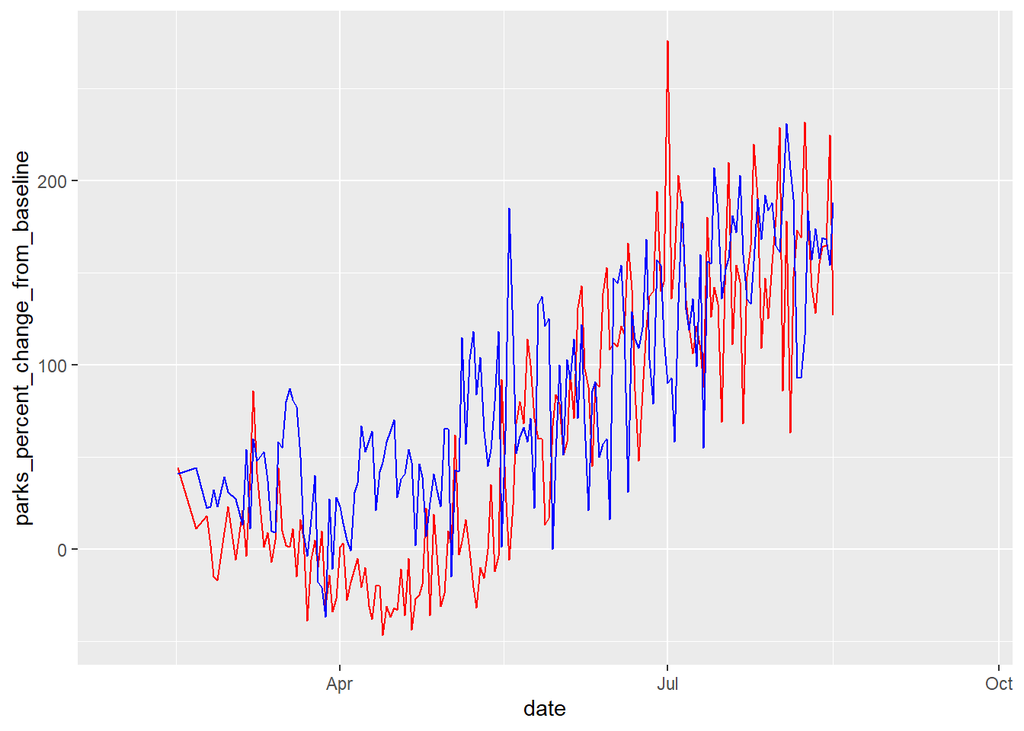

```r
parks_bc_ontario <- ggplot() +
   geom_line(data = ontario, mapping = aes(x = date, y = parks_percent_change_from_baseline), color = "red") +
   geom_line(data = bc, mapping = aes(x = date, y = parks_percent_change_from_baseline), color = "blue")
parks_bc_ontario
```

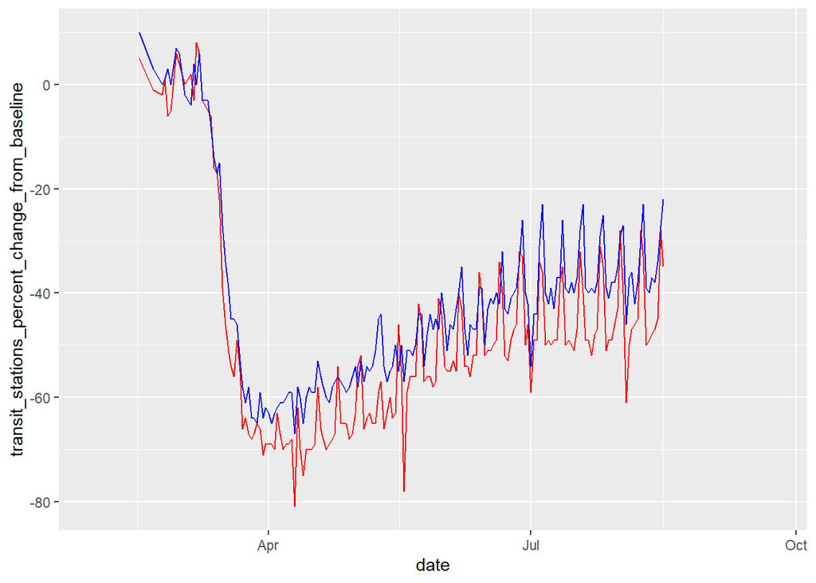

```r
transit_bc_ontario <- ggplot() +
   geom_line(data = ontario, mapping = aes(x = date, y = transit_stations_percent_change_from_baseline), color = "red") +
   geom_line(data = bc, mapping = aes(x = date, y = transit_stations_percent_change_from_baseline), color = "blue")
transit_bc_ontario
```

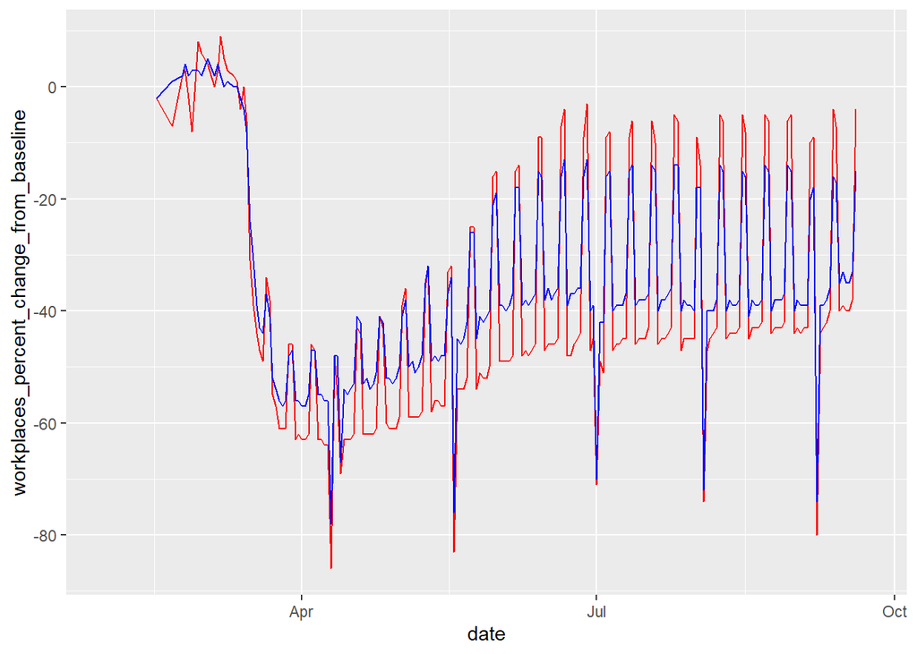

```r
workplaces_bc_ontario <- ggplot() +
   geom_line(data = ontario, mapping = aes(x = date, y = workplaces_percent_change_from_baseline), color = "red") +
   geom_line(data = bc, mapping = aes(x = date, y = workplaces_percent_change_from_baseline), color = "blue")
workplaces_bc_ontario
```

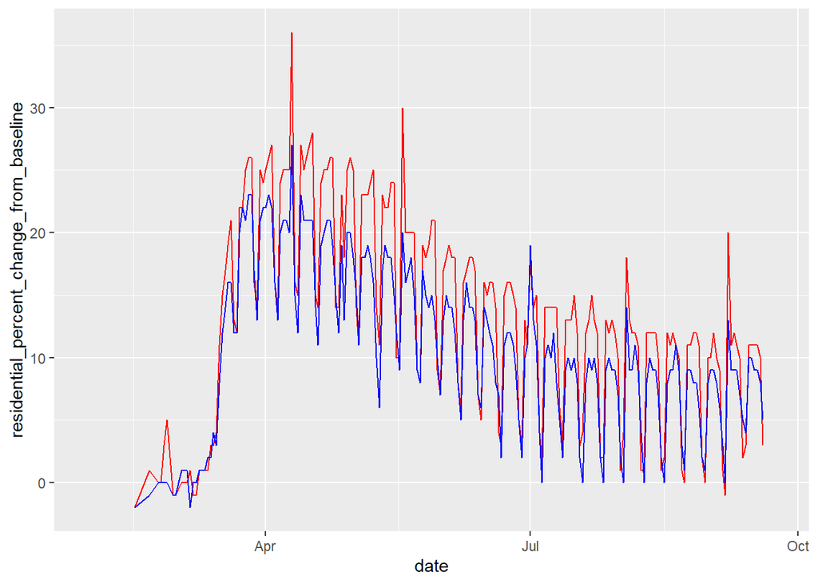

```r
residential_bc_ontario <- ggplot() +
   geom_line(data = ontario, mapping = aes(x = date, y = residential_percent_change_from_baseline), color = "red") +
   geom_line(data = bc, mapping = aes(x = date, y = residential_percent_change_from_baseline), color = "blue")
residential_bc_ontario
```

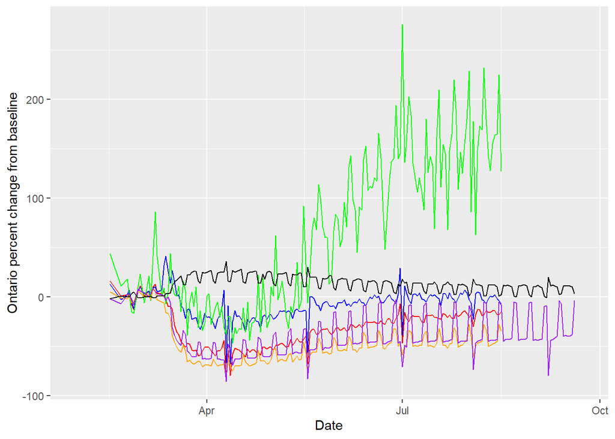

```r
ggplot(data = ontario, mapping = aes(x = date, y = retail_and_recreation_percent_change_from_baseline)) +
   geom_line(color = "red") +
   labs(x = "Date", y = "Ontario percent change from baseline") +
   geom_line(data = ontario, aes(date, grocery_and_pharmacy_percent_change_from_baseline), color = "blue") +
   geom_line(data = ontario, aes(date, parks_percent_change_from_baseline), color = "green") +
   geom_line(data = ontario, aes(date, transit_stations_percent_change_from_baseline), color = "orange") +
   geom_line(data = ontario, aes(date, workplaces_percent_change_from_baseline), color = "purple") +
   geom_line(data = ontario, aes(date, residential_percent_change_from_baseline), color = "black")
```

```r
ggplot
```

[output not shown]

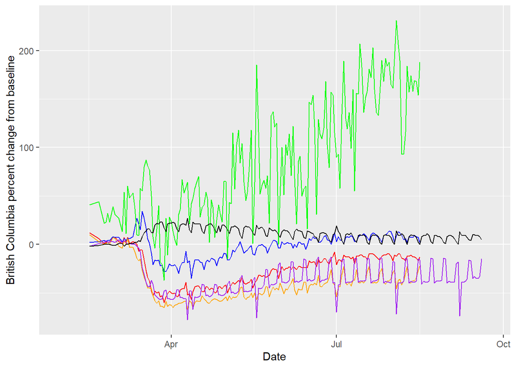

```r
ggplot(data = bc, mapping = aes(x = date, y = retail_and_recreation_percent_change_from_baseline)) +
   geom_line(color = "red") +
   labs(x = "Date", y = "British Columbia percent change from baseline") +
   geom_line(data = bc, aes(date, grocery_and_pharmacy_percent_change_from_baseline), color = "blue") +
   geom_line(data = bc, aes(date, parks_percent_change_from_baseline), color = "green") +
   geom_line(data = bc, aes(date, transit_stations_percent_change_from_baseline), color = "orange") +
   geom_line(data = bc, aes(date, workplaces_percent_change_from_baseline), color = "purple") +
   geom_line(data = bc, aes(date, residential_percent_change_from_baseline), color = "black")
```

```r
ggplot
```

[output not shown]

```
Interpret your results: overall, how are
people behaving differently with COVID-19?  How do people's behaviours
differ between Ontario and British Columbia?
```

Answer: More people were staying home in Ontario than in British Columbia. This is particularly apparent in the residential, workplace, and transit plots. More people in British Columbia were out at the parks at least from April - June, while more people in Ontario headed to the parks in July. Ontario shows a deeper decline in retail and grocery plots, but you can also see very similar upticks and downswings among both provinces in these plots.